# Trabajo Final

**Estudiantes:**

Dawa Méndez Álvarez

Daniel Villavicencio Serrano

# **Distribución natural de *Bothriechis schlegelli* en Costa Rica**

## **Introducción**

*Bothriechis schlegelii*, conocida como la víbora de pestañas o **bocaracá**, es una especie de serpiente venenosa ampliamente distribuida en los bosques húmedos de Costa Rica. Se caracteriza por su cuerpo esbelto, su variabilidad de color que va desde el verde brillante hasta tonos amarillos y marrones, y sus distintivas escamas supraoculares alargadas, que le dan la apariencia de "pestañas".

[figure not shown]

Esta serpiente es un depredador eficiente que utiliza la caza al acecho, **camuflándose entre la vegetación** para emboscar pequeños vertebrados. Su importancia en los ecosistemas radica en su papel como regulador de poblaciones de presas y como indicador de la salud de los bosques tropicales. En Costa Rica, además, es una especie emblemática dentro de la herpetofauna y es clave en el ecoturismo y la educación ambiental, generando conciencia sobre la conservación de los ecosistemas donde habita.

[figure not shown]

Se buscó una base de datos de GBIF, donde se filtró para tener registros solo de Costa Rica.

GBIF.org (03 March 2025) GBIF Occurrence Download https://doi.org/10.15468/dl.vqa2ch

# **Desarrollo**

## I Parte

Definir librerías y complementos a utilizar

```python
#Cargar e importar librerías
import geopandas as gpd
import pandas as pd
import plotly.express as px
import folium
from folium import Choropleth
import matplotlib.pyplot as plt
!pip install mapclassify --quiet
import mapclassify
import rasterio
import geopandas as gpd
import matplotlib.pyplot as plt
```

```
   ━━━━━━━━━━━━━━━━━━━━━━━━━━━━━━━━━━━━━━━━ 59.1/59.1 kB 1.6 MB/s eta 0:00:00
```

## II Parte

Cargar base de datos y crear los *dataframes y geodataframes* a utilizar

```python
# Importar datos desde un CSV.
bocaraca_df = pd.read_csv(
    'https://raw.githubusercontent.com/villa27/GBIF/refs/heads/main/Bocaraca_CR.csv',
    sep='\t'
)

# Crear un GeoDataFrame a partir del DataFrame
bocaraca_gdf = gpd.GeoDataFrame(
    bocaraca_df,
    geometry=gpd.points_from_xy(bocaraca_df.decimalLongitude, bocaraca_df.decimalLatitude),
    crs='EPSG:4326'
)

# Mostrar los primeros registros del GeoDataFrame,
# incluyendo la columna de geometría
bocaraca_gdf[['gbifID', 'species', 'decimalLongitude', 'decimalLatitude', 'geometry']].head()
```

|  | gbifID | species | decimalLongitude | decimalLatitude | geometry |
| --- | --- | --- | --- | --- | --- |
| 0 | 911921901 | Bothriechis schlegelii | -84.689033 | 10.503133 | POINT (-84.68903 10.50313) |
| 1 | 894770240 | Bothriechis schlegelii | -84.300000 | 10.933333 | POINT (-84.3 10.93333) |
| 2 | 786457126 | Bothriechis schlegelii | -82.830000 | 9.630000 | POINT (-82.83 9.63) |
| 3 | 786457123 | Bothriechis schlegelii | -82.830000 | 9.630000 | POINT (-82.83 9.63) |
| 4 | 786449863 | Bothriechis schlegelii | -82.830000 | 9.630000 | POINT (-82.83 9.63) |

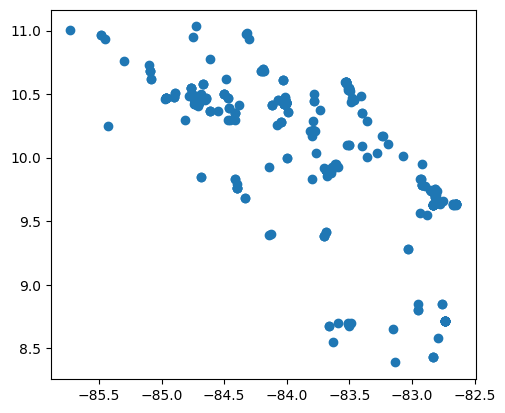

```python
# Mapa estático de registros de bocaraca
bocaraca_gdf.plot()
```

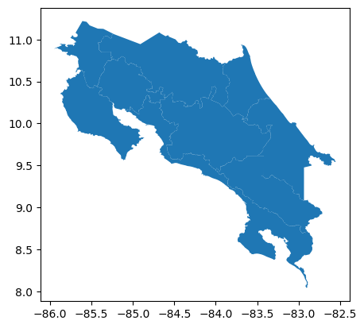

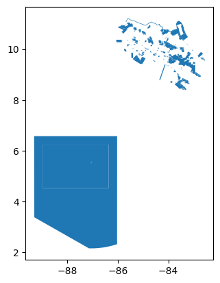

```python
# Crear un geodataframe con datos y Área de Conservación
AC_gdf = gpd.read_file(
    'https://raw.githubusercontent.com/villa27/GBIF/refs/heads/main/AC.gpkg'
)

# Crear un geodataframe con datos y Área Silvestre Protegida
ASP_gdf = gpd.read_file(
    'https://raw.githubusercontent.com/villa27/GBIF/refs/heads/main/ASP.gpkg'
)

# Mostrar los primeros registros del GeoDataFrame,
# incluyendo la columna de geometría
#AC_gdf[['fid', 'nombre_ac', 'siglas_ac', 'geometry']].head()
AC_gdf.plot()
ASP_gdf.plot()
```

```python
# Convertir el DataFrame de especies a un GeoDataFrame

df = bocaraca_df.dropna(subset=['decimalLongitude', 'decimalLatitude'])  # Eliminar filas sin coordenadas # Asignar bocaraca_df a df

gdf_especies = gpd.GeoDataFrame(df,
                                geometry=gpd.points_from_xy(df['decimalLongitude'], df['decimalLatitude']),
                                crs="EPSG:4326")  # Asegurar sistema de coordenadas WGS84
```

## III Parte

Estadístiscos para demostrar la distribución natural de la **Bocaracá** en Costa Rica.

```python
# Realizar el cruce espacial entre los registros y los polígonos
gdf_joined = gpd.sjoin(bocaraca_gdf, AC_gdf, how="left", predicate="within")

# Contar el número total de registros por Área de Conservación
registros_por_AC = gdf_joined.groupby('siglas_ac').size().reset_index()

# Renombrar las columnas
registros_por_AC.columns = ['siglas_ac', 'Cantidad de Registros']

# Ordenar los datos de mayor a menor
registros_por_AC = registros_por_AC.sort_values(by='Cantidad de Registros', ascending=False)

# Mostrar la tabla final
print(registros_por_AC)
```

```
  siglas_ac  Cantidad de Registros
0     ACAHN                    104
4     ACLAC                     93
2       ACC                     64
9      ACTo                     34
1      ACAT                     20
7     ACOSA                     10
5     ACLAP                      8
3       ACG                      5
6    ACOPAC                      5
8       ACT                      1
```

-Mediante plotly, genere un gráfico interactivo (ej. de barras) que muestre la riqueza de especies en cada polígono.

Según los datos del código anterior.

```python
# Crear un gráfico de barras interactivo
fig = px.bar(registros_por_AC,
             x='siglas_ac', # Changed from 'siglas_AC' to 'siglas_ac'
             y='Cantidad de Registros',
             title="Riqueza de Especies por Área de Conservación en Costa Rica",
             labels={'Riqueza de Especies': 'Número de Especies'},
             color='Cantidad de Registros',
             color_continuous_scale='viridis')

# Mostrar el gráfico
fig.show()
```

[interactive chart not shown]

Según el gráfico el Área de Conservación Arenal Huétar Norte (ACAHN) es la región donde más registros se han presentado de la serpiente Bothriechis schlegelii, mientras que el Área de Conservación Tempisque es la zona con menos registros.

Se puede interpretar que los factores climáticos de cada zona tienen influencia sobre la distribución de la espcie (Pizzigalli et al., 2020; Ramírez et al., 2019).

```python
# Realizar el cruce espacial entre los registros y los polígonos
gdf_joined = gpd.sjoin(bocaraca_gdf, ASP_gdf, how="left", predicate="within")

# Contar el número total de registros por Área Silvestre Protegida
registros_por_ASP = gdf_joined.groupby('nombre_asp').size().reset_index()

# Renombrar las columnas
registros_por_ASP.columns = ['nombre_asp', 'Cantidad de Registros']

# Ordenar los datos de mayor a menor
registros_por_ASP = registros_por_ASP.sort_values(by='Cantidad de Registros', ascending=False)

# Mostrar la tabla final
print(registros_por_ASP)
```

```
                       nombre_asp  Cantidad de Registros
4                         Cahuita                     36
10                       La Selva                     24
1                          Arenal                     20
17                     Tortuguero                     11
2              Barra del Colorado                     10
6              Gandoca Manzanillo                      7
7                     Golfo Dulce                      3
8                      Guanacaste                      3
9        Internacional La Amistad                      2
11                   La Tirimbina                      2
14  Miravalles-Jorge Manuel Dengo                      1
16             Rincon de la Vieja                      1
15                 Pacuare Matina                      1
0      Acuiferos Guacimo y Pococi                      1
13                      Maquenque                      1
12                 Manuel Antonio                      1
5                       Corcovado                      1
3                Braulio Carrillo                      1
18               Volcan Turrialba                      1
```

Mediante folium, genere un mapa de coropletas interactivo que muestre la riqueza de especies en cada polígono.

```python
# Crear un gráfico de lineas interactivo
fig = px.line(registros_por_ASP,
             x='nombre_asp',
             y='Cantidad de Registros',
             title="Riqueza de Especies por Área de Conservación en Costa Rica",
             labels={'Riqueza de Especies': 'Número de Especies'},
                   color_discrete_sequence=['blue']
             )

# Mostrar el gráfico
fig.show()
```

[interactive chart not shown]

En cuanto a las Áreas Silvestres Protegidas se observa un comportamiento similar, donde Cahuita, La Selva, Arenal y Tortuguero son las zonas con mayor incidencia de la serpiente.

```python
from google.colab import output
output.enable_custom_widget_manager()
```

```python
# Crear mapa leafmap
m = leafmap.Map(center=[9.6, -84.2], zoom=7, height="400px")  # Zoom to Costa Rica

m.add_data(
    ASP_gdf,
    column="siglas_cat",
    scheme="NaturalBreaks",
    cmap="gist_earth",
    legend_title="Categoría de manejo",
    categorical=True
)

# Desplegar el mapa
m
```

```
Map(center=[9.6, -84.2], controls=(ZoomControl(options=['position', 'zoom_in_text', 'zoom_in_title', 'zoom_out…
```

```python
from google.colab import output
output.disable_custom_widget_manager()
```

```python
# Mapa interactivo de registros de Bocaraca
bocaraca_gdf[(bocaraca_gdf['decimalLongitude'] < 0) & (bocaraca_gdf['decimalLatitude'] < 16)].explore()
```

Make this Notebook Trusted to load map: File -> Trust Notebook

[interactive chart not shown]

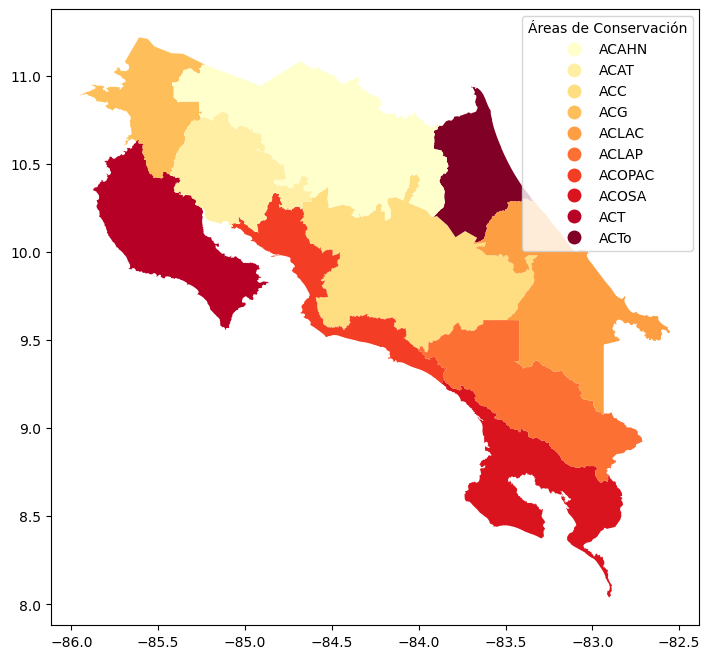

```python
# Mapa de coropletas
AC_gdf.plot(
    column='siglas_ac',
    cmap='YlOrRd', # https://matplotlib.org/stable/gallery/color/colormap_reference.html
    legend=True,
    legend_kwds={
        'title': "Áreas de Conservación", # Changed 'label' to 'title'
        # Removed 'orientation': "horizontal" as it is not a valid keyword argument here
        # You can use plt.gca().legend().set_bbox_to_anchor((x,y)) for positioning the legend or
    },
    figsize=(12, 8)
)
```

```python
# Instalación de rasterio
!pip install rasterio --quiet
```

```python
# Carga de rasterio
import rasterio

# Carga de rasterio.plot (para graficar datos raster)
import rasterio.plot

# Carga de numpy (para álgebra lineal)
import numpy as np

# Carga de matplotlib.pyplot
import matplotlib.pyplot as plt
```

```python
# Carga de datos de elevacion
elevacion = rasterio.open(
    'https://raw.githubusercontent.com/villa27/GBIF/refs/heads/main/wc2.1_2.5m_elev.tif'
)

print(elevacion)
print(f"Ancho: {elevacion.width}")
print(f"Alto: {elevacion.height}")
print(f"Número de bandas: {elevacion.count}")
print(f"CRS: {elevacion.crs}")
print(f"Transformación: {elevacion.transform}")
print(f"Tipos de datos: {elevacion.dtypes}")
print(f"Límites: {elevacion.bounds}")
```

```
<open DatasetReader name='https://raw.githubusercontent.com/villa27/GBIF/refs/heads/main/wc2.1_2.5m_elev.tif' mode='r'>
Ancho: 8640
Alto: 4320
Número de bandas: 1
CRS: EPSG:4326
Transformación: | 0.04, 0.00,-180.00|
| 0.00,-0.04, 90.00|
| 0.00, 0.00, 1.00|
Tipos de datos: ('int16',)
Límites: BoundingBox(left=-180.0, bottom=-90.0, right=180.0, top=90.0)
```

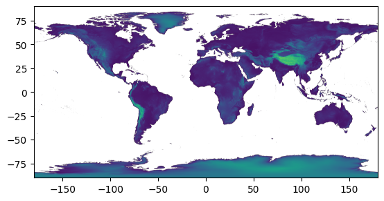

```python
# Mapa de elevación
rasterio.plot.show(elevacion)
```

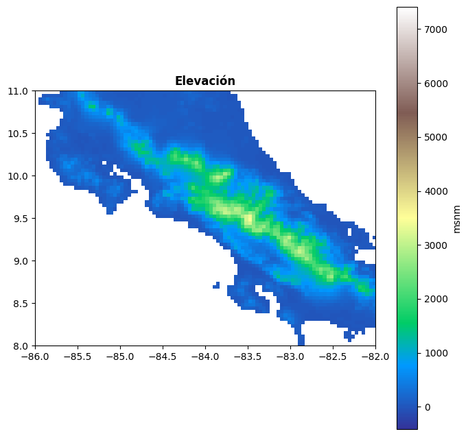

```python
fig, ax = plt.subplots(figsize=(8, 8))

# Mapa de elevacion
rasterio.plot.show(
    elevacion,
    cmap="terrain", # colores
    ax=ax,
    title="Elevación"
)

# Agregar una leyenda
cbar = fig.colorbar(ax.images[0], ax=ax, shrink=1)
cbar.set_label('msnm')

# Limitar el rango de los ejes
ax.set_xlim(-86, -82)
ax.set_ylim(8, 11)

plt.show()
```

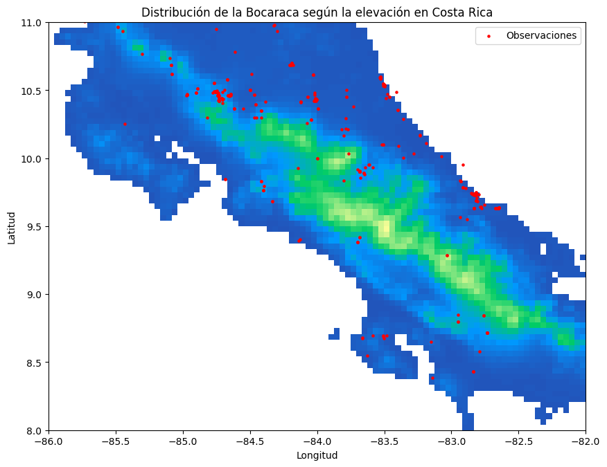

```python
# Cargar datos de elevación
with rasterio.open('https://raw.githubusercontent.com/villa27/GBIF/refs/heads/main/wc2.1_2.5m_elev.tif') as elevacion:

    # Cargar datos de ubicaciones
    ubicaciones = gpd.read_file('https://raw.githubusercontent.com/villa27/GBIF/refs/heads/main/Bocaraca_CR.csv',
                                 sep='\t',  # Asumiendo valores separados por tabulaciones en el CSV
                                 encoding='latin-1'  # Manejar posibles problemas de codificación
                                 )
    # Convertir 'decimalLongitude' y 'decimalLatitude' a numérico
    ubicaciones['decimalLongitude'] = pd.to_numeric(ubicaciones['decimalLongitude'], errors='coerce')
    ubicaciones['decimalLatitude'] = pd.to_numeric(ubicaciones['decimalLatitude'], errors='coerce')

    # Crear columna de geometría si no existe
    if 'geometry' not in ubicaciones.columns:
        ubicaciones = gpd.GeoDataFrame(
            ubicaciones,
            geometry=gpd.points_from_xy(ubicaciones.decimalLongitude, ubicaciones.decimalLatitude),
            crs='EPSG:4326'
        )
    else:
        # Asegurar que la columna de geometría esté en el formato correcto
        ubicaciones['geometry'] = gpd.GeoSeries.from_wkt(ubicaciones['geometry'])
        ubicaciones = ubicaciones.set_crs('EPSG:4326')


    # Crear la gráfica
    fig, ax = plt.subplots(figsize=(10, 10))

    # Mostrar datos de elevación
    rasterio.plot.show(elevacion, ax=ax, cmap='terrain')

    # Mostrar datos de ubicaciones
    ubicaciones.plot(ax=ax, marker='o', color='red', markersize=5, label='Observaciones')

    # Agregar título, etiquetas y leyenda
    plt.title('Distribución de la Bocaraca según la elevación en Costa Rica')
    plt.xlabel('Longitud')
    plt.ylabel('Latitud')
    plt.legend()

    # Hacer zoom en Costa Rica
    ax.set_xlim(-86, -82)
    ax.set_ylim(8, 11)

    plt.show()
```

# **Conclusiones**

Realizar estudios sobre la distribución y riqueza de las especies, permite tomar desiciones para su conservación y manejo

El uso de herramientas y plataformas como GBIF, en conjunto con Python facilita el análisis y estudio de las especies, más en paises como Costa Rica con alta diversidad y politicas de conservación

# **Referencias bibliográficas**

Díaz Gómez, S. M., & Molina Betancourth, K. J. (2022). Modelos de distribución potencial de las serpientes venenosas Bothrops asper, Bothrops punctatus y *Bothriechis schlegelii* con aportes al conocimiento del accidente ofídico en el departamento Caldas, Colombia.

Sorrell, G. G. (2009). Diel movement and predation activity patterns of the eyelash palm-pitviper (*Bothriechis schlegelii*). Copeia, 2009(1), 105-109.

Ramirez-Arce, D., Vega-Coto, J. O. N. A. T. H. A. N., Zúñiga-Ortiz, A., Artavia-León, A., Baaijen, W., & WasKo, D. K. (2019). Snake diversity (Squamata: Serpentes) in Quebrada González Sector of Braulio Carrillo National Park, Costa Rica. Herpetological Conservation and Biology, 14(1), 212-222.

Pizzigalli, C., Banfi, F., Ficetola, G. F., Falaschi, M., Mangiacotti, M., Sacchi, R., ... & Scali, S. (2020). Eco-geographical determinants of the evolution of ornamentation in vipers. Biological Journal of the Linnean Society, 130(2), 345-358.